# Instalacja Dependencji

Teraz wykomentowana ponieważ komunikat o instalowanych package'ach był bardzo długi

```python
# !conda install -y pandas
# !conda install -y numpy
# !conda install -y matplotlib
# !conda install -y seaborn=0.10.1
```

# Pobranie Danych

```python
# Builtins
import io

# 3rd party
import google.datalab.storage as storage
import google.datalab.bigquery as bq
from google.datalab import Context
import matplotlib as mpl
import matplotlib.pyplot as plt
import numpy as np
import pandas as pd
import seaborn as sns
```

```python
# Bucket
countries_bucket = storage.Bucket("countries_info")
# Csv's
general_info_csv = countries_bucket.object("country_general_info.csv")
happiness_info_2015_csv = countries_bucket.object("hapiness_by_year/2015.csv")
happiness_info_2016_csv = countries_bucket.object("hapiness_by_year/2016.csv")
happiness_info_2017_csv = countries_bucket.object("hapiness_by_year/2017.csv")
happiness_info_2018_csv = countries_bucket.object("hapiness_by_year/2018.csv")
happiness_info_2019_csv = countries_bucket.object("hapiness_by_year/2019.csv")
```

```python
# Dataframes
general = pd.read_csv(io.BytesIO(general_info_csv.read_stream()), delimiter=",", decimal=",")
h_15 = pd.read_csv(io.BytesIO(happiness_info_2015_csv.read_stream()), delimiter=",")
h_16 = pd.read_csv(io.BytesIO(happiness_info_2016_csv.read_stream()), delimiter=",")
h_17 = pd.read_csv(io.BytesIO(happiness_info_2017_csv.read_stream()), delimiter=",")
h_18 = pd.read_csv(io.BytesIO(happiness_info_2018_csv.read_stream()), delimiter=",")
h_19 = pd.read_csv(io.BytesIO(happiness_info_2019_csv.read_stream()), delimiter=",")
dfs = [general, h_15, h_16, h_17, h_18, h_19]
```

```python
general.head()
```

|  | Country | Region | Population | Area (sq. mi.) | Pop. Density (per sq. mi.) | Coastline (coast/area ratio) | Net migration | Infant mortality (per 1000 births) | GDP ($ per capita) | Literacy (%) | Phones (per 1000) | Arable (%) | Crops (%) | Other (%) | Climate | Birthrate | Deathrate | Agriculture | Industry | Service |
| --- | --- | --- | --- | --- | --- | --- | --- | --- | --- | --- | --- | --- | --- | --- | --- | --- | --- | --- | --- | --- |
| 0 | Afghanistan | ASIA (EX. NEAR EAST) | 31056997 | 647500 | 48.0 | 0.00 | 23.06 | 163.07 | 700.0 | 36.0 | 3.2 | 12.13 | 0.22 | 87.65 | 1.0 | 46.60 | 20.34 | 0.380 | 0.240 | 0.380 |
| 1 | Albania | EASTERN EUROPE | 3581655 | 28748 | 124.6 | 1.26 | -4.93 | 21.52 | 4500.0 | 86.5 | 71.2 | 21.09 | 4.42 | 74.49 | 3.0 | 15.11 | 5.22 | 0.232 | 0.188 | 0.579 |
| 2 | Algeria | NORTHERN AFRICA | 32930091 | 2381740 | 13.8 | 0.04 | -0.39 | 31.00 | 6000.0 | 70.0 | 78.1 | 3.22 | 0.25 | 96.53 | 1.0 | 17.14 | 4.61 | 0.101 | 0.600 | 0.298 |
| 3 | American Samoa | OCEANIA | 57794 | 199 | 290.4 | 58.29 | -20.71 | 9.27 | 8000.0 | 97.0 | 259.5 | 10.00 | 15.00 | 75.00 | 2.0 | 22.46 | 3.27 | NaN | NaN | NaN |
| 4 | Andorra | WESTERN EUROPE | 71201 | 468 | 152.1 | 0.00 | 6.60 | 4.05 | 19000.0 | 100.0 | 497.2 | 2.22 | 0.00 | 97.78 | 3.0 | 8.71 | 6.25 | NaN | NaN | NaN |

```python
h_15.head()
```

|  | Country | Region | Happiness Rank | Happiness Score | Standard Error | Economy (GDP per Capita) | Family | Health (Life Expectancy) | Freedom | Trust (Government Corruption) | Generosity | Dystopia Residual |
| --- | --- | --- | --- | --- | --- | --- | --- | --- | --- | --- | --- | --- |
| 0 | Switzerland | Western Europe | 1 | 7.587 | 0.03411 | 1.39651 | 1.34951 | 0.94143 | 0.66557 | 0.41978 | 0.29678 | 2.51738 |
| 1 | Iceland | Western Europe | 2 | 7.561 | 0.04884 | 1.30232 | 1.40223 | 0.94784 | 0.62877 | 0.14145 | 0.43630 | 2.70201 |
| 2 | Denmark | Western Europe | 3 | 7.527 | 0.03328 | 1.32548 | 1.36058 | 0.87464 | 0.64938 | 0.48357 | 0.34139 | 2.49204 |
| 3 | Norway | Western Europe | 4 | 7.522 | 0.03880 | 1.45900 | 1.33095 | 0.88521 | 0.66973 | 0.36503 | 0.34699 | 2.46531 |
| 4 | Canada | North America | 5 | 7.427 | 0.03553 | 1.32629 | 1.32261 | 0.90563 | 0.63297 | 0.32957 | 0.45811 | 2.45176 |

# Znaczenie danych liczbowych w kolumnach - happiness

Happiness Score - uczestnicy badań mieli ocenić poziom szczęścia (0 - 10)  
Reszta to znormalizowanie współczynniki użyte do obliczenia jak mocno dany aspekt wpływa na satysfakcje z życia w kraju

# Sprawdzanie Czystości

```python
for df in dfs:
  print("#############")
  print(df.isna().sum())
```

```
#############
Country                                0
Region                                 0
Population                             0
Area (sq. mi.)                         0
Pop. Density (per sq. mi.)             0
Coastline (coast/area ratio)           0
Net migration                          3
Infant mortality (per 1000 births)     3
GDP ($ per capita)                     1
Literacy (%)                          18
Phones (per 1000)                      4
Arable (%)                             2
Crops (%)                              2
Other (%)                              2
Climate                               22
Birthrate                              3
Deathrate                              4
Agriculture                           15
Industry                              16
Service                               15
dtype: int64
#############
Country                          0
Region                           0
Happiness Rank                   0
Happiness Score                  0
Standard Error                   0
Economy (GDP per Capita)         0
Family                           0
Health (Life Expectancy)         0
Freedom                          0
Trust (Government Corruption)    0
Generosity                       0
Dystopia Residual                0
dtype: int64
#############
Country                          0
Region                           0
Happiness Rank                   0
```

[output cut: 32 more lines]

```
Freedom to make life choices    0
Generosity                      0
Perceptions of corruption       1
dtype: int64
#############
Overall rank                    0
Country or region               0
Score                           0
GDP per capita                  0
Social support                  0
Healthy life expectancy         0
Freedom to make life choices    0
Generosity                      0
Perceptions of corruption       0
dtype: int64
```

### Informacje ogólne mają pare brakujących miejsc ale wypełnienie ich średnią powinno być w tym wypadku sensowne.

### Widać ,że dane dotyczące szczęścia są bardzo czyste, jednak dane z poszczególnych lat różnią się między sobą kolumnami

```python
for df in dfs:
  for column in df.columns:
    print(column, end=", ")
  print()
```

```
Country, Region, Population, Area (sq. mi.), Pop. Density (per sq. mi.), Coastline (coast/area ratio), Net migration, Infant mortality (per 1000 births), GDP ($ per capita), Literacy (%), Phones (per 1000), Arable (%), Crops (%), Other (%), Climate, Birthrate, Deathrate, Agriculture, Industry, Servi…
Country, Region, Happiness Rank, Happiness Score, Standard Error, Economy (GDP per Capita), Family, Health (Life Expectancy), Freedom, Trust (Government Corruption), Generosity, Dystopia Residual,
Country, Region, Happiness Rank, Happiness Score, Lower Confidence Interval, Upper Confidence Interval, Economy (GDP per Capita), Family, Health (Life Expectancy), Freedom, Trust (Government Corruption), Generosity, Dystopia Residual,
Country, Happiness.Rank, Happiness.Score, Whisker.high, Whisker.low, Economy..GDP.per.Capita., Family, Health..Life.Expectancy., Freedom, Generosity, Trust..Government.Corruption., Dystopia.Residual,
Overall rank, Country or region, Score, GDP per capita, Social support, Healthy life expectancy, Freedom to make life choices, Generosity, Perceptions of corruption,
Overall rank, Country or region, Score, GDP per capita, Social support, Healthy life expectancy, Freedom to make life choices, Generosity, Perceptions of corruption,
```

```python
h_19.head()
```

|  | Overall rank | Country or region | Score | GDP per capita | Social support | Healthy life expectancy | Freedom to make life choices | Generosity | Perceptions of corruption |
| --- | --- | --- | --- | --- | --- | --- | --- | --- | --- |
| 0 | 1 | Finland | 7.769 | 1.340 | 1.587 | 0.986 | 0.596 | 0.153 | 0.393 |
| 1 | 2 | Denmark | 7.600 | 1.383 | 1.573 | 0.996 | 0.592 | 0.252 | 0.410 |
| 2 | 3 | Norway | 7.554 | 1.488 | 1.582 | 1.028 | 0.603 | 0.271 | 0.341 |
| 3 | 4 | Iceland | 7.494 | 1.380 | 1.624 | 1.026 | 0.591 | 0.354 | 0.118 |
| 4 | 5 | Netherlands | 7.488 | 1.396 | 1.522 | 0.999 | 0.557 | 0.322 | 0.298 |

```python
h_17.head()
```

|  | Country | Happiness.Rank | Happiness.Score | Whisker.high | Whisker.low | Economy..GDP.per.Capita. | Family | Health..Life.Expectancy. | Freedom | Generosity | Trust..Government.Corruption. | Dystopia.Residual |
| --- | --- | --- | --- | --- | --- | --- | --- | --- | --- | --- | --- | --- |
| 0 | Norway | 1 | 7.537 | 7.594445 | 7.479556 | 1.616463 | 1.533524 | 0.796667 | 0.635423 | 0.362012 | 0.315964 | 2.277027 |
| 1 | Denmark | 2 | 7.522 | 7.581728 | 7.462272 | 1.482383 | 1.551122 | 0.792566 | 0.626007 | 0.355280 | 0.400770 | 2.313707 |
| 2 | Iceland | 3 | 7.504 | 7.622030 | 7.385970 | 1.480633 | 1.610574 | 0.833552 | 0.627163 | 0.475540 | 0.153527 | 2.322715 |
| 3 | Switzerland | 4 | 7.494 | 7.561772 | 7.426227 | 1.564980 | 1.516912 | 0.858131 | 0.620071 | 0.290549 | 0.367007 | 2.276716 |
| 4 | Finland | 5 | 7.469 | 7.527542 | 7.410458 | 1.443572 | 1.540247 | 0.809158 | 0.617951 | 0.245483 | 0.382612 | 2.430182 |

```python
h_15.head()
```

|  | Country | Region | Happiness Rank | Happiness Score | Standard Error | Economy (GDP per Capita) | Family | Health (Life Expectancy) | Freedom | Trust (Government Corruption) | Generosity | Dystopia Residual |
| --- | --- | --- | --- | --- | --- | --- | --- | --- | --- | --- | --- | --- |
| 0 | Switzerland | Western Europe | 1 | 7.587 | 0.03411 | 1.39651 | 1.34951 | 0.94143 | 0.66557 | 0.41978 | 0.29678 | 2.51738 |
| 1 | Iceland | Western Europe | 2 | 7.561 | 0.04884 | 1.30232 | 1.40223 | 0.94784 | 0.62877 | 0.14145 | 0.43630 | 2.70201 |
| 2 | Denmark | Western Europe | 3 | 7.527 | 0.03328 | 1.32548 | 1.36058 | 0.87464 | 0.64938 | 0.48357 | 0.34139 | 2.49204 |
| 3 | Norway | Western Europe | 4 | 7.522 | 0.03880 | 1.45900 | 1.33095 | 0.88521 | 0.66973 | 0.36503 | 0.34699 | 2.46531 |
| 4 | Canada | North America | 5 | 7.427 | 0.03553 | 1.32629 | 1.32261 | 0.90563 | 0.63297 | 0.32957 | 0.45811 | 2.45176 |

```python
h_17.columns = ["Country", "Happiness Rank", "Happiness Score", "wh", "wl", "Economy (GDP per Capita)",
                "Family", "Health (Life Expectancy)", "Freedom", "Generosity", "Trust (Government Corruption)", "Dystopia Residual"]
```

```python
h_17.head()
```

|  | Country | Happiness Rank | Happiness Score | wh | wl | Economy (GDP per Capita) | Family | Health (Life Expectancy) | Freedom | Generosity | Trust (Government Corruption) | Dystopia Residual |
| --- | --- | --- | --- | --- | --- | --- | --- | --- | --- | --- | --- | --- |
| 0 | Norway | 1 | 7.537 | 7.594445 | 7.479556 | 1.616463 | 1.533524 | 0.796667 | 0.635423 | 0.362012 | 0.315964 | 2.277027 |
| 1 | Denmark | 2 | 7.522 | 7.581728 | 7.462272 | 1.482383 | 1.551122 | 0.792566 | 0.626007 | 0.355280 | 0.400770 | 2.313707 |
| 2 | Iceland | 3 | 7.504 | 7.622030 | 7.385970 | 1.480633 | 1.610574 | 0.833552 | 0.627163 | 0.475540 | 0.153527 | 2.322715 |
| 3 | Switzerland | 4 | 7.494 | 7.561772 | 7.426227 | 1.564980 | 1.516912 | 0.858131 | 0.620071 | 0.290549 | 0.367007 | 2.276716 |
| 4 | Finland | 5 | 7.469 | 7.527542 | 7.410458 | 1.443572 | 1.540247 | 0.809158 | 0.617951 | 0.245483 | 0.382612 | 2.430182 |

```python
h_15.head()
```

|  | Country | Region | Happiness Rank | Happiness Score | Standard Error | Economy (GDP per Capita) | Family | Health (Life Expectancy) | Freedom | Trust (Government Corruption) | Generosity | Dystopia Residual |
| --- | --- | --- | --- | --- | --- | --- | --- | --- | --- | --- | --- | --- |
| 0 | Switzerland | Western Europe | 1 | 7.587 | 0.03411 | 1.39651 | 1.34951 | 0.94143 | 0.66557 | 0.41978 | 0.29678 | 2.51738 |
| 1 | Iceland | Western Europe | 2 | 7.561 | 0.04884 | 1.30232 | 1.40223 | 0.94784 | 0.62877 | 0.14145 | 0.43630 | 2.70201 |
| 2 | Denmark | Western Europe | 3 | 7.527 | 0.03328 | 1.32548 | 1.36058 | 0.87464 | 0.64938 | 0.48357 | 0.34139 | 2.49204 |
| 3 | Norway | Western Europe | 4 | 7.522 | 0.03880 | 1.45900 | 1.33095 | 0.88521 | 0.66973 | 0.36503 | 0.34699 | 2.46531 |
| 4 | Canada | North America | 5 | 7.427 | 0.03553 | 1.32629 | 1.32261 | 0.90563 | 0.63297 | 0.32957 | 0.45811 | 2.45176 |

```python
h_15 = h_15.drop(["Region", "Standard Error", "Dystopia Residual"], axis=1)
```

```python
h_17 = h_17.drop(["wh", "wl", "Dystopia Residual"], axis=1)
```

```python
h_15.head()
```

|  | Country | Happiness Rank | Happiness Score | Economy (GDP per Capita) | Family | Health (Life Expectancy) | Freedom | Trust (Government Corruption) | Generosity |
| --- | --- | --- | --- | --- | --- | --- | --- | --- | --- |
| 0 | Switzerland | 1 | 7.587 | 1.39651 | 1.34951 | 0.94143 | 0.66557 | 0.41978 | 0.29678 |
| 1 | Iceland | 2 | 7.561 | 1.30232 | 1.40223 | 0.94784 | 0.62877 | 0.14145 | 0.43630 |
| 2 | Denmark | 3 | 7.527 | 1.32548 | 1.36058 | 0.87464 | 0.64938 | 0.48357 | 0.34139 |
| 3 | Norway | 4 | 7.522 | 1.45900 | 1.33095 | 0.88521 | 0.66973 | 0.36503 | 0.34699 |
| 4 | Canada | 5 | 7.427 | 1.32629 | 1.32261 | 0.90563 | 0.63297 | 0.32957 | 0.45811 |

```python
h_17.head()
```

|  | Country | Happiness Rank | Happiness Score | Economy (GDP per Capita) | Family | Health (Life Expectancy) | Freedom | Generosity | Trust (Government Corruption) |
| --- | --- | --- | --- | --- | --- | --- | --- | --- | --- |
| 0 | Norway | 1 | 7.537 | 1.616463 | 1.533524 | 0.796667 | 0.635423 | 0.362012 | 0.315964 |
| 1 | Denmark | 2 | 7.522 | 1.482383 | 1.551122 | 0.792566 | 0.626007 | 0.355280 | 0.400770 |
| 2 | Iceland | 3 | 7.504 | 1.480633 | 1.610574 | 0.833552 | 0.627163 | 0.475540 | 0.153527 |
| 3 | Switzerland | 4 | 7.494 | 1.564980 | 1.516912 | 0.858131 | 0.620071 | 0.290549 | 0.367007 |
| 4 | Finland | 5 | 7.469 | 1.443572 | 1.540247 | 0.809158 | 0.617951 | 0.245483 | 0.382612 |

```python
h_16.head()
```

|  | Country | Region | Happiness Rank | Happiness Score | Lower Confidence Interval | Upper Confidence Interval | Economy (GDP per Capita) | Family | Health (Life Expectancy) | Freedom | Trust (Government Corruption) | Generosity | Dystopia Residual |
| --- | --- | --- | --- | --- | --- | --- | --- | --- | --- | --- | --- | --- | --- |
| 0 | Denmark | Western Europe | 1 | 7.526 | 7.460 | 7.592 | 1.44178 | 1.16374 | 0.79504 | 0.57941 | 0.44453 | 0.36171 | 2.73939 |
| 1 | Switzerland | Western Europe | 2 | 7.509 | 7.428 | 7.590 | 1.52733 | 1.14524 | 0.86303 | 0.58557 | 0.41203 | 0.28083 | 2.69463 |
| 2 | Iceland | Western Europe | 3 | 7.501 | 7.333 | 7.669 | 1.42666 | 1.18326 | 0.86733 | 0.56624 | 0.14975 | 0.47678 | 2.83137 |
| 3 | Norway | Western Europe | 4 | 7.498 | 7.421 | 7.575 | 1.57744 | 1.12690 | 0.79579 | 0.59609 | 0.35776 | 0.37895 | 2.66465 |
| 4 | Finland | Western Europe | 5 | 7.413 | 7.351 | 7.475 | 1.40598 | 1.13464 | 0.81091 | 0.57104 | 0.41004 | 0.25492 | 2.82596 |

```python
h_16 = h_16.drop(["Region", "Lower Confidence Interval", "Upper Confidence Interval", "Dystopia Residual"], axis=1)
```

```python
def print_columns(dfs):
  for df in dfs:
    for column in df.columns:
      print(column, end=", ")
    print()
```

```python
print_columns([h_15, h_16, h_17])
```

```
Country, Happiness Rank, Happiness Score, Economy (GDP per Capita), Family, Health (Life Expectancy), Freedom, Trust (Government Corruption), Generosity,
Country, Happiness Rank, Happiness Score, Economy (GDP per Capita), Family, Health (Life Expectancy), Freedom, Trust (Government Corruption), Generosity,
Country, Happiness Rank, Happiness Score, Economy (GDP per Capita), Family, Health (Life Expectancy), Freedom, Generosity, Trust (Government Corruption),
```

```python
h_18.head()
```

|  | Overall rank | Country or region | Score | GDP per capita | Social support | Healthy life expectancy | Freedom to make life choices | Generosity | Perceptions of corruption |
| --- | --- | --- | --- | --- | --- | --- | --- | --- | --- |
| 0 | 1 | Finland | 7.632 | 1.305 | 1.592 | 0.874 | 0.681 | 0.202 | 0.393 |
| 1 | 2 | Norway | 7.594 | 1.456 | 1.582 | 0.861 | 0.686 | 0.286 | 0.340 |
| 2 | 3 | Denmark | 7.555 | 1.351 | 1.590 | 0.868 | 0.683 | 0.284 | 0.408 |
| 3 | 4 | Iceland | 7.495 | 1.343 | 1.644 | 0.914 | 0.677 | 0.353 | 0.138 |
| 4 | 5 | Switzerland | 7.487 | 1.420 | 1.549 | 0.927 | 0.660 | 0.256 | 0.357 |

```python
h_19.head()
```

|  | Overall rank | Country or region | Score | GDP per capita | Social support | Healthy life expectancy | Freedom to make life choices | Generosity | Perceptions of corruption |
| --- | --- | --- | --- | --- | --- | --- | --- | --- | --- |
| 0 | 1 | Finland | 7.769 | 1.340 | 1.587 | 0.986 | 0.596 | 0.153 | 0.393 |
| 1 | 2 | Denmark | 7.600 | 1.383 | 1.573 | 0.996 | 0.592 | 0.252 | 0.410 |
| 2 | 3 | Norway | 7.554 | 1.488 | 1.582 | 1.028 | 0.603 | 0.271 | 0.341 |
| 3 | 4 | Iceland | 7.494 | 1.380 | 1.624 | 1.026 | 0.591 | 0.354 | 0.118 |
| 4 | 5 | Netherlands | 7.488 | 1.396 | 1.522 | 0.999 | 0.557 | 0.322 | 0.298 |

```python
h_18.columns = ["Happiness Rank", "Country", "Happiness Score", "Economy (GDP per Capita)", "Family", "Health (Life Expectancy)", "Freedom", "Generosity", "Trust (Government Corruption)"]
h_19.columns = ["Happiness Rank", "Country", "Happiness Score", "Economy (GDP per Capita)", "Family", "Health (Life Expectancy)", "Freedom", "Generosity", "Trust (Government Corruption)"]
```

```python
print_columns([h_15, h_16, h_17, h_18, h_19])
```

```
Country, Happiness Rank, Happiness Score, Economy (GDP per Capita), Family, Health (Life Expectancy), Freedom, Trust (Government Corruption), Generosity,
Country, Happiness Rank, Happiness Score, Economy (GDP per Capita), Family, Health (Life Expectancy), Freedom, Trust (Government Corruption), Generosity,
Country, Happiness Rank, Happiness Score, Economy (GDP per Capita), Family, Health (Life Expectancy), Freedom, Generosity, Trust (Government Corruption),
Happiness Rank, Country, Happiness Score, Economy (GDP per Capita), Family, Health (Life Expectancy), Freedom, Generosity, Trust (Government Corruption),
Happiness Rank, Country, Happiness Score, Economy (GDP per Capita), Family, Health (Life Expectancy), Freedom, Generosity, Trust (Government Corruption),
```

### Teraz mamy takie same tabele dla każdego roku, wyrzucone kolumny nie zawierały krytycznie istotnych danych

```python
general.head()
```

|  | Country | Region | Population | Area (sq. mi.) | Pop. Density (per sq. mi.) | Coastline (coast/area ratio) | Net migration | Infant mortality (per 1000 births) | GDP ($ per capita) | Literacy (%) | Phones (per 1000) | Arable (%) | Crops (%) | Other (%) | Climate | Birthrate | Deathrate | Agriculture | Industry | Service |
| --- | --- | --- | --- | --- | --- | --- | --- | --- | --- | --- | --- | --- | --- | --- | --- | --- | --- | --- | --- | --- |
| 0 | Afghanistan | ASIA (EX. NEAR EAST) | 31056997 | 647500 | 48.0 | 0.00 | 23.06 | 163.07 | 700.0 | 36.0 | 3.2 | 12.13 | 0.22 | 87.65 | 1.0 | 46.60 | 20.34 | 0.380 | 0.240 | 0.380 |
| 1 | Albania | EASTERN EUROPE | 3581655 | 28748 | 124.6 | 1.26 | -4.93 | 21.52 | 4500.0 | 86.5 | 71.2 | 21.09 | 4.42 | 74.49 | 3.0 | 15.11 | 5.22 | 0.232 | 0.188 | 0.579 |
| 2 | Algeria | NORTHERN AFRICA | 32930091 | 2381740 | 13.8 | 0.04 | -0.39 | 31.00 | 6000.0 | 70.0 | 78.1 | 3.22 | 0.25 | 96.53 | 1.0 | 17.14 | 4.61 | 0.101 | 0.600 | 0.298 |
| 3 | American Samoa | OCEANIA | 57794 | 199 | 290.4 | 58.29 | -20.71 | 9.27 | 8000.0 | 97.0 | 259.5 | 10.00 | 15.00 | 75.00 | 2.0 | 22.46 | 3.27 | NaN | NaN | NaN |
| 4 | Andorra | WESTERN EUROPE | 71201 | 468 | 152.1 | 0.00 | 6.60 | 4.05 | 19000.0 | 100.0 | 497.2 | 2.22 | 0.00 | 97.78 | 3.0 | 8.71 | 6.25 | NaN | NaN | NaN |

# Znaczenie niektórych kolumn

Arable - % powierzchni kraju możwily do uprawy roli  
Crops - % już wykorzystywany  
Agriculture, Industry, Service - udział % danego sektora w ekonomii  
Deathrate - zgony na 1000 osób  
Birthrate - urodzenia na 1000 osób  
Infant Mortality - zgody na 1000 narodzin  
Net migration - imigrants - emigrants / mid year population

```python
general["Climate"].value_counts()
```

```
2.0    111
3.0     48
1.0     29
1.5      8
4.0      6
2.5      3
Name: Climate, dtype: int64
```

### Climate meaning

1. Dry tropical or tundra and ice, classification B and E.
2. Wet tropical, classification A.
3. Temperate humid subtropical and temperate continental, classification Cfa, Cwa, and D.
4. Dry hot summers and wet winters
5. 1,5 i 2,5 to klimaty pośrednie między 1 i 2 oraz 2 i 3

```python
general = general.drop(["Region"], axis=1)
```

```python
general.head()
```

|  | Country | Population | Area (sq. mi.) | Pop. Density (per sq. mi.) | Coastline (coast/area ratio) | Net migration | Infant mortality (per 1000 births) | GDP ($ per capita) | Literacy (%) | Phones (per 1000) | Arable (%) | Crops (%) | Other (%) | Climate | Birthrate | Deathrate | Agriculture | Industry | Service |
| --- | --- | --- | --- | --- | --- | --- | --- | --- | --- | --- | --- | --- | --- | --- | --- | --- | --- | --- | --- |
| 0 | Afghanistan | 31056997 | 647500 | 48.0 | 0.00 | 23.06 | 163.07 | 700.0 | 36.0 | 3.2 | 12.13 | 0.22 | 87.65 | 1.0 | 46.60 | 20.34 | 0.380 | 0.240 | 0.380 |
| 1 | Albania | 3581655 | 28748 | 124.6 | 1.26 | -4.93 | 21.52 | 4500.0 | 86.5 | 71.2 | 21.09 | 4.42 | 74.49 | 3.0 | 15.11 | 5.22 | 0.232 | 0.188 | 0.579 |
| 2 | Algeria | 32930091 | 2381740 | 13.8 | 0.04 | -0.39 | 31.00 | 6000.0 | 70.0 | 78.1 | 3.22 | 0.25 | 96.53 | 1.0 | 17.14 | 4.61 | 0.101 | 0.600 | 0.298 |
| 3 | American Samoa | 57794 | 199 | 290.4 | 58.29 | -20.71 | 9.27 | 8000.0 | 97.0 | 259.5 | 10.00 | 15.00 | 75.00 | 2.0 | 22.46 | 3.27 | NaN | NaN | NaN |
| 4 | Andorra | 71201 | 468 | 152.1 | 0.00 | 6.60 | 4.05 | 19000.0 | 100.0 | 497.2 | 2.22 | 0.00 | 97.78 | 3.0 | 8.71 | 6.25 | NaN | NaN | NaN |

## Typy danych kolumn

```python
general.dtypes
```

```
Country                                object
Population                              int64
Area (sq. mi.)                          int64
Pop. Density (per sq. mi.)            float64
Coastline (coast/area ratio)          float64
Net migration                         float64
Infant mortality (per 1000 births)    float64
GDP ($ per capita)                    float64
Literacy (%)                          float64
Phones (per 1000)                     float64
Arable (%)                            float64
Crops (%)                             float64
Other (%)                             float64
Climate                               float64
Birthrate                             float64
Deathrate                             float64
Agriculture                           float64
Industry                              float64
Service                               float64
dtype: object
```

```python
h_15.dtypes
```

```
Country                           object
Happiness Rank                     int64
Happiness Score                  float64
Economy (GDP per Capita)         float64
Family                           float64
Health (Life Expectancy)         float64
Freedom                          float64
Trust (Government Corruption)    float64
Generosity                       float64
dtype: object
```

# Eksploracja danych

## Połączenie tabel

```python
general.head()
general.loc[general["Country"] == "Canada"]
```

|  | Country | Population | Area (sq. mi.) | Pop. Density (per sq. mi.) | Coastline (coast/area ratio) | Net migration | Infant mortality (per 1000 births) | GDP ($ per capita) | Literacy (%) | Phones (per 1000) | Arable (%) | Crops (%) | Other (%) | Climate | Birthrate | Deathrate | Agriculture | Industry | Service |
| --- | --- | --- | --- | --- | --- | --- | --- | --- | --- | --- | --- | --- | --- | --- | --- | --- | --- | --- | --- |

```python
general.head()
general.loc[general["Country"] == "Canada "]
```

|  | Country | Population | Area (sq. mi.) | Pop. Density (per sq. mi.) | Coastline (coast/area ratio) | Net migration | Infant mortality (per 1000 births) | GDP ($ per capita) | Literacy (%) | Phones (per 1000) | Arable (%) | Crops (%) | Other (%) | Climate | Birthrate | Deathrate | Agriculture | Industry | Service |
| --- | --- | --- | --- | --- | --- | --- | --- | --- | --- | --- | --- | --- | --- | --- | --- | --- | --- | --- | --- |
| 36 | Canada | 33098932 | 9984670 | 3.3 | 2.02 | 5.96 | 4.75 | 29800.0 | 97.0 | 552.2 | 4.96 | 0.02 | 95.02 | NaN | 10.78 | 7.8 | 0.022 | 0.294 | 0.684 |

```python
h_15.head()
h_15.loc[h_15["Country"] == "Canada"]
```

|  | Country | Happiness Rank | Happiness Score | Economy (GDP per Capita) | Family | Health (Life Expectancy) | Freedom | Trust (Government Corruption) | Generosity |
| --- | --- | --- | --- | --- | --- | --- | --- | --- | --- |
| 4 | Canada | 5 | 7.427 | 1.32629 | 1.32261 | 0.90563 | 0.63297 | 0.32957 | 0.45811 |

### Ta trailing spacja to poważny problem, wszystkie merge nie zadziałają jak trzeba

```python
general["Country"] = general["Country"].str.rstrip()
```

```python
general.head()
general.loc[general["Country"] == "Canada"]
```

|  | Country | Population | Area (sq. mi.) | Pop. Density (per sq. mi.) | Coastline (coast/area ratio) | Net migration | Infant mortality (per 1000 births) | GDP ($ per capita) | Literacy (%) | Phones (per 1000) | Arable (%) | Crops (%) | Other (%) | Climate | Birthrate | Deathrate | Agriculture | Industry | Service |
| --- | --- | --- | --- | --- | --- | --- | --- | --- | --- | --- | --- | --- | --- | --- | --- | --- | --- | --- | --- |
| 36 | Canada | 33098932 | 9984670 | 3.3 | 2.02 | 5.96 | 4.75 | 29800.0 | 97.0 | 552.2 | 4.96 | 0.02 | 95.02 | NaN | 10.78 | 7.8 | 0.022 | 0.294 | 0.684 |

```python
mh_15 = pd.merge(general, h_15, on="Country", how="inner")
mh_16 = pd.merge(general, h_16, on="Country", how="inner")
mh_17 = pd.merge(general, h_17, on="Country", how="inner")
mh_18 = pd.merge(general, h_18, on="Country", how="inner")
mh_19 = pd.merge(general, h_19, on="Country", how="inner")
```

## Klimat a szczęście

```python
mh_15["Climate"].value_counts()
```

```
2.0    51
3.0    39
1.0    25
1.5     7
4.0     4
2.5     3
Name: Climate, dtype: int64
```

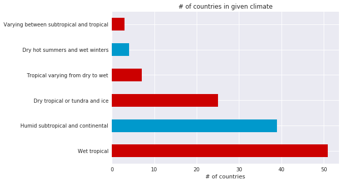

```python
mpl.style.use("seaborn")
mh_15["Climate"].value_counts().plot(kind="barh", color=["#CC0000", "#0099CC"])
climates = ("Wet tropical", "Humid subtropical and continental", "Dry tropical or tundra and ice", "Tropical varying from dry to wet",
          "Dry hot summers and wet winters", "Varying between subtropical and tropical")
plt.yticks(np.arange(len(climates)), climates)
plt.xlabel("# of countries")
plt.title("# of countries in given climate")
countries_in_climate_plot = plt.figure()
plt.show()
```

```python
cmh_15 = mh_15.groupby(["Country", "Happiness Score", "Climate"])["Climate"].count().to_frame(name="hp").reset_index()
```

```python
cmh_15 = cmh_15.drop(["hp"], axis=1)
```

```python
cmh_15.head()
```

|  | Country | Happiness Score | Climate |
| --- | --- | --- | --- |
| 0 | Afghanistan | 3.575 | 1.0 |
| 1 | Albania | 4.959 | 3.0 |
| 2 | Algeria | 5.605 | 1.0 |
| 3 | Argentina | 6.574 | 3.0 |
| 4 | Armenia | 4.350 | 4.0 |

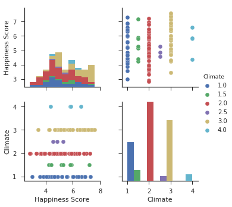

```python
sns.set(style="ticks")
climate_plot = sns.pairplot(cmh_15, hue="Climate")
```

### Kropki ciągną się po całośći - klimat nie ma znaczenia

# Korelacje

```python
mh_15.head()
```

|  | Country | Population | Area (sq. mi.) | Pop. Density (per sq. mi.) | Coastline (coast/area ratio) | Net migration | Infant mortality (per 1000 births) | GDP ($ per capita) | Literacy (%) | Phones (per 1000) | ... | Industry | Service | Happiness Rank | Happiness Score | Economy (GDP per Capita) | Family | Health (Life Expectancy) | Freedom | Trust (Government Corruption) | Generosity |
| --- | --- | --- | --- | --- | --- | --- | --- | --- | --- | --- | --- | --- | --- | --- | --- | --- | --- | --- | --- | --- | --- |
| 0 | Afghanistan | 31056997 | 647500 | 48.0 | 0.00 | 23.06 | 163.07 | 700.0 | 36.0 | 3.2 | ... | 0.240 | 0.380 | 153 | 3.575 | 0.31982 | 0.30285 | 0.30335 | 0.23414 | 0.09719 | 0.36510 |
| 1 | Albania | 3581655 | 28748 | 124.6 | 1.26 | -4.93 | 21.52 | 4500.0 | 86.5 | 71.2 | ... | 0.188 | 0.579 | 95 | 4.959 | 0.87867 | 0.80434 | 0.81325 | 0.35733 | 0.06413 | 0.14272 |
| 2 | Algeria | 32930091 | 2381740 | 13.8 | 0.04 | -0.39 | 31.00 | 6000.0 | 70.0 | 78.1 | ... | 0.600 | 0.298 | 68 | 5.605 | 0.93929 | 1.07772 | 0.61766 | 0.28579 | 0.17383 | 0.07822 |
| 3 | Angola | 12127071 | 1246700 | 9.7 | 0.13 | 0.00 | 191.19 | 1900.0 | 42.0 | 7.8 | ... | 0.658 | 0.246 | 137 | 4.033 | 0.75778 | 0.86040 | 0.16683 | 0.10384 | 0.07122 | 0.12344 |
| 4 | Argentina | 39921833 | 2766890 | 14.4 | 0.18 | 0.61 | 15.18 | 11200.0 | 97.1 | 220.4 | ... | 0.358 | 0.547 | 30 | 6.574 | 1.05351 | 1.24823 | 0.78723 | 0.44974 | 0.08484 | 0.11451 |

5 rows × 27 columns

```python
mh_15.dtypes
```

```
Country                                object
Population                              int64
Area (sq. mi.)                          int64
Pop. Density (per sq. mi.)            float64
Coastline (coast/area ratio)          float64
Net migration                         float64
Infant mortality (per 1000 births)    float64
GDP ($ per capita)                    float64
Literacy (%)                          float64
Phones (per 1000)                     float64
Arable (%)                            float64
Crops (%)                             float64
Other (%)                             float64
Climate                               float64
Birthrate                             float64
Deathrate                             float64
Agriculture                           float64
Industry                              float64
Service                               float64
Happiness Rank                          int64
Happiness Score                       float64
Economy (GDP per Capita)              float64
Family                                float64
Health (Life Expectancy)              float64
Freedom                               float64
Trust (Government Corruption)         float64
Generosity                            float64
dtype: object
```

```python
cor_15 = mh_15.drop(["Family", "Freedom", "Health (Life Expectancy)", "Trust (Government Corruption)", "Generosity", "Economy (GDP per Capita)", "Happiness Rank", "Country"], axis=1)
cor_15.head()
```

|  | Population | Area (sq. mi.) | Pop. Density (per sq. mi.) | Coastline (coast/area ratio) | Net migration | Infant mortality (per 1000 births) | GDP ($ per capita) | Literacy (%) | Phones (per 1000) | Arable (%) | Crops (%) | Other (%) | Climate | Birthrate | Deathrate | Agriculture | Industry | Service | Happiness Score |
| --- | --- | --- | --- | --- | --- | --- | --- | --- | --- | --- | --- | --- | --- | --- | --- | --- | --- | --- | --- |
| 0 | 31056997 | 647500 | 48.0 | 0.00 | 23.06 | 163.07 | 700.0 | 36.0 | 3.2 | 12.13 | 0.22 | 87.65 | 1.0 | 46.60 | 20.34 | 0.380 | 0.240 | 0.380 | 3.575 |
| 1 | 3581655 | 28748 | 124.6 | 1.26 | -4.93 | 21.52 | 4500.0 | 86.5 | 71.2 | 21.09 | 4.42 | 74.49 | 3.0 | 15.11 | 5.22 | 0.232 | 0.188 | 0.579 | 4.959 |
| 2 | 32930091 | 2381740 | 13.8 | 0.04 | -0.39 | 31.00 | 6000.0 | 70.0 | 78.1 | 3.22 | 0.25 | 96.53 | 1.0 | 17.14 | 4.61 | 0.101 | 0.600 | 0.298 | 5.605 |
| 3 | 12127071 | 1246700 | 9.7 | 0.13 | 0.00 | 191.19 | 1900.0 | 42.0 | 7.8 | 2.41 | 0.24 | 97.35 | NaN | 45.11 | 24.20 | 0.096 | 0.658 | 0.246 | 4.033 |
| 4 | 39921833 | 2766890 | 14.4 | 0.18 | 0.61 | 15.18 | 11200.0 | 97.1 | 220.4 | 12.31 | 0.48 | 87.21 | 3.0 | 16.73 | 7.55 | 0.095 | 0.358 | 0.547 | 6.574 |

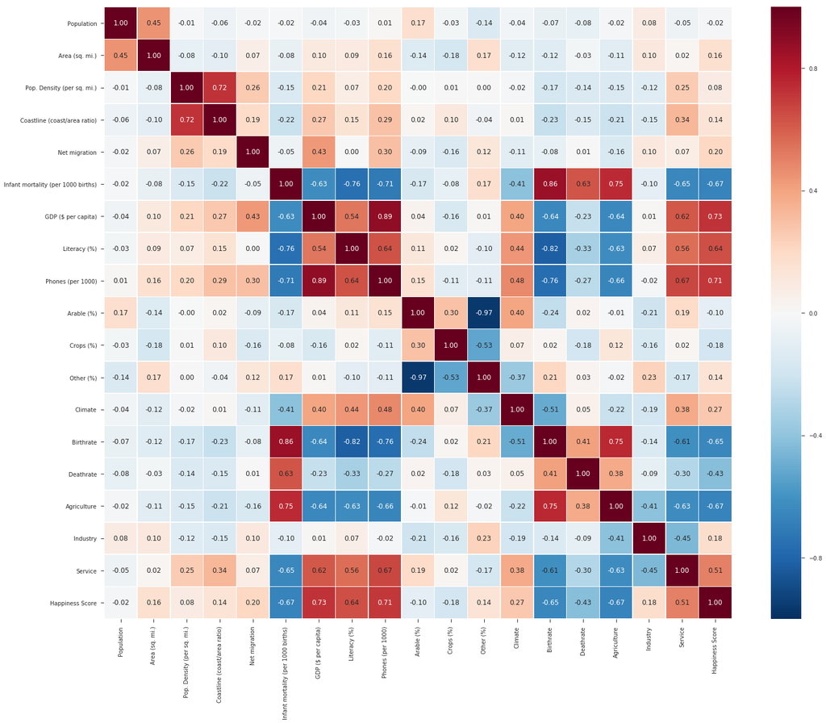

```python
corr_matrix = cor_15.corr()
fig, ax = plt.subplots(figsize=(25,20))
ax = sns.heatmap(corr_matrix,
                annot=True,
                linewidths=0.5,
                fmt=".2f"
               )
```

## Interpretacja Heatmap'y

Najważniejsza dla tego projektu jest ostatni wiersz pokazujący korelacje Happiness Score / x  
Wysokie dodatnie wartości przy GDP, Literacy i Phones oznaczają "jedna rośnie gdy rośnie druga" tzn. Im wyższe GDP kraju tym szczęśliwsi mieszkańcy  
Analogicznie wysokie ujemne wartośći przy Infant Mortality, Deathrate i Agriculture pokazują "im więcej ludzi umiera i im więcej rolników tym ludzie mniej szczęśliwi

# Ploty zależności

```python
cor_15.head()
```

|  | Population | Area (sq. mi.) | Pop. Density (per sq. mi.) | Coastline (coast/area ratio) | Net migration | Infant mortality (per 1000 births) | GDP ($ per capita) | Literacy (%) | Phones (per 1000) | Arable (%) | Crops (%) | Other (%) | Climate | Birthrate | Deathrate | Agriculture | Industry | Service | Happiness Score |
| --- | --- | --- | --- | --- | --- | --- | --- | --- | --- | --- | --- | --- | --- | --- | --- | --- | --- | --- | --- |
| 0 | 31056997 | 647500 | 48.0 | 0.00 | 23.06 | 163.07 | 700.0 | 36.0 | 3.2 | 12.13 | 0.22 | 87.65 | 1.0 | 46.60 | 20.34 | 0.380 | 0.240 | 0.380 | 3.575 |
| 1 | 3581655 | 28748 | 124.6 | 1.26 | -4.93 | 21.52 | 4500.0 | 86.5 | 71.2 | 21.09 | 4.42 | 74.49 | 3.0 | 15.11 | 5.22 | 0.232 | 0.188 | 0.579 | 4.959 |
| 2 | 32930091 | 2381740 | 13.8 | 0.04 | -0.39 | 31.00 | 6000.0 | 70.0 | 78.1 | 3.22 | 0.25 | 96.53 | 1.0 | 17.14 | 4.61 | 0.101 | 0.600 | 0.298 | 5.605 |
| 3 | 12127071 | 1246700 | 9.7 | 0.13 | 0.00 | 191.19 | 1900.0 | 42.0 | 7.8 | 2.41 | 0.24 | 97.35 | NaN | 45.11 | 24.20 | 0.096 | 0.658 | 0.246 | 4.033 |
| 4 | 39921833 | 2766890 | 14.4 | 0.18 | 0.61 | 15.18 | 11200.0 | 97.1 | 220.4 | 12.31 | 0.48 | 87.21 | 3.0 | 16.73 | 7.55 | 0.095 | 0.358 | 0.547 | 6.574 |

```python
def plot_graph(cor, col):
  mpl.style.use("seaborn")
  plt.plot(cor_15["Happiness Score"], cor_15[cor], 'ro' ,color=col)
  plt.xlabel("Happines Score")
  plt.ylabel(cor)
  fig = plt.figure()
  plt.show()
  return fig
```

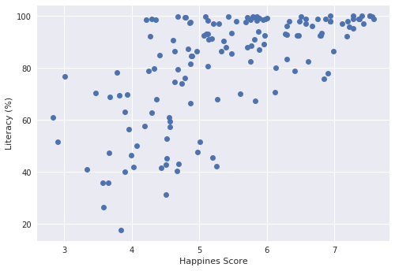

```python
literacy = plot_graph('Literacy (%)', "C0")
```

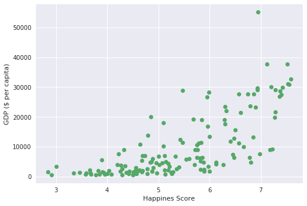

```python
gdp = plot_graph("GDP ($ per capita)", "C1")
```

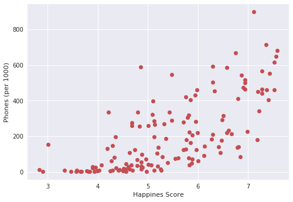

```python
phones = plot_graph("Phones (per 1000)", "C2")
```

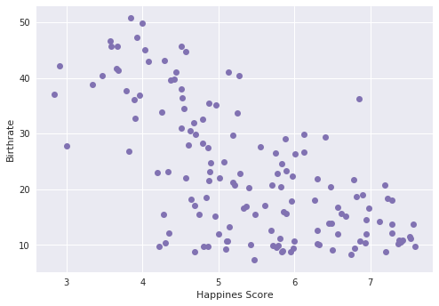

```python
birthrate = plot_graph("Birthrate", "C3")
```

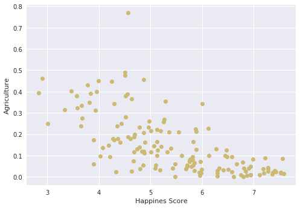

```python
agriculture = plot_graph("Agriculture", "C4")
```

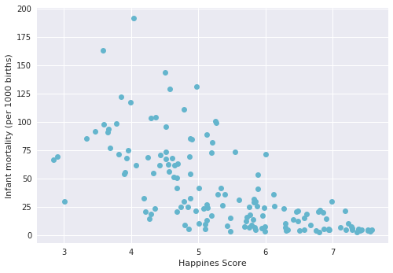

```python
infant_mort = plot_graph("Infant mortality (per 1000 births)", "C5")
```

# Eksport analizy

```python
mh_15.to_csv("2015_data.csv", index=False)
mh_16.to_csv("2016_data.csv", index=False)
mh_17.to_csv("2017_data.csv", index=False)
mh_18.to_csv("2018_data.csv", index=False)
mh_19.to_csv("2019_data.csv", index=False)
```

```python
countries_in_climate_plot.savefig("countries_in_climate.png")
fig.savefig("heatmap.png")
climate_plot.savefig("climate_vs_happiness.png")
literacy.savefig("literacy.png")
gdp.savefig("gdp.png")
phones.savefig("phones.png")
agriculture.savefig("agriculture.png")
infant_mort.savefig("infant_mort.png")
birthrate.savefig("birthrate.png")
```

## Trzeba skonwertować nazwy tabel bo bq ma problem

```python
mh_15.columns = ['country', 'population', 'area_sq_mi', 'pop_density_per_sq_mi',
       'coastline_coast_by_area_ratio', 'net_migration',
       'infant_mortality_per_1000_births', 'gdp_dollar_per_capita',
       'literacy_percent', 'phones_per_1000', 'arable_percent', 'crops_percent',
       'other_land_percent', 'climate_type', 'birthrate_per_1000', 'deathrate_per_1000', 'agriculture_share',
       'industry_share', 'service_share', 'happiness_rank', 'happiness_score',
       'economy_gdp_per_capita', 'family', 'health',
       'freedom', 'trust', 'generosity']
mh_16.columns = ['country', 'population', 'area_sq_mi', 'pop_density_per_sq_mi',
       'coastline_coast_by_area_ratio', 'net_migration',
       'infant_mortality_per_1000_births', 'gdp_dollar_per_capita',
       'literacy_percent', 'phones_per_1000', 'arable_percent', 'crops_percent',
       'other_land_percent', 'climate_type', 'birthrate_per_1000', 'deathrate_per_1000', 'agriculture_share',
       'industry_share', 'service_share', 'happiness_rank', 'happiness_score',
       'economy_gdp_per_capita', 'family', 'health',
       'freedom', 'trust', 'generosity']
mh_17.columns = ['country', 'population', 'area_sq_mi', 'pop_density_per_sq_mi',
       'coastline_coast_by_area_ratio', 'net_migration',
       'infant_mortality_per_1000_births', 'gdp_dollar_per_capita',
       'literacy_percent', 'phones_per_1000', 'arable_percent', 'crops_percent',
       'other_land_percent', 'climate_type', 'birthrate_per_1000', 'deathrate_per_1000', 'agriculture_share',
       'industry_share', 'service_share', 'happiness_rank', 'happiness_score',
       'economy_gdp_per_capita', 'family', 'health',
       'freedom', 'trust', 'generosity']
mh_18.columns = ['country', 'population', 'area_sq_mi', 'pop_density_per_sq_mi',
       'coastline_coast_by_area_ratio', 'net_migration',
       'infant_mortality_per_1000_births', 'gdp_dollar_per_capita',
       'literacy_percent', 'phones_per_1000', 'arable_percent', 'crops_percent',
       'other_land_percent', 'climate_type', 'birthrate_per_1000', 'deathrate_per_1000', 'agriculture_share',
       'industry_share', 'service_share', 'happiness_rank', 'happiness_score',
       'economy_gdp_per_capita', 'family', 'health',
       'freedom', 'generosity', 'trust']
mh_19.columns = ['country', 'population', 'area_sq_mi', 'pop_density_per_sq_mi',
       'coastline_coast_by_area_ratio', 'net_migration',
       'infant_mortality_per_1000_births', 'gdp_dollar_per_capita',
       'literacy_percent', 'phones_per_1000', 'arable_percent', 'crops_percent',
       'other_land_percent', 'climate_type', 'birthrate_per_1000', 'deathrate_per_1000', 'agriculture_share',
       'industry_share', 'service_share', 'happiness_rank', 'happiness_score',
       'economy_gdp_per_capita', 'family', 'health',
       'freedom', 'generosity', 'trust']
```

## I jeszcze NaN'y uzupełnić bo też ma problem

```python
# 2015
mh_15["climate_type"] = mh_15["climate_type"].fillna(1.0)
mh_15["phones_per_1000"] = mh_15["phones_per_1000"].fillna(mh_15["phones_per_1000"].mean())
mh_15["literacy_percent"] = mh_15["literacy_percent"].fillna(mh_15["literacy_percent"].mean())
mh_15["birthrate_per_1000"] = mh_15["birthrate_per_1000"].fillna(mh_15["birthrate_per_1000"].mean())
mh_15["deathrate_per_1000"] = mh_15["deathrate_per_1000"].fillna(mh_15["deathrate_per_1000"].mean())
# 2016
mh_16["climate_type"] = mh_16["climate_type"].fillna(1.0)
mh_16["phones_per_1000"] = mh_16["phones_per_1000"].fillna(mh_16["phones_per_1000"].mean())
mh_16["literacy_percent"] = mh_16["literacy_percent"].fillna(mh_16["literacy_percent"].mean())
mh_16["birthrate_per_1000"] = mh_16["birthrate_per_1000"].fillna(mh_16["birthrate_per_1000"].mean())
mh_16["deathrate_per_1000"] = mh_16["deathrate_per_1000"].fillna(mh_16["deathrate_per_1000"].mean())
# 2017
mh_17["climate_type"] = mh_17["climate_type"].fillna(1.0)
mh_17["phones_per_1000"] = mh_17["phones_per_1000"].fillna(mh_17["phones_per_1000"].mean())
mh_17["literacy_percent"] = mh_17["literacy_percent"].fillna(mh_17["literacy_percent"].mean())
mh_17["birthrate_per_1000"] = mh_17["birthrate_per_1000"].fillna(mh_17["birthrate_per_1000"].mean())
mh_17["deathrate_per_1000"] = mh_17["deathrate_per_1000"].fillna(mh_17["deathrate_per_1000"].mean())
# 2018
mh_18["climate_type"] = mh_18["climate_type"].fillna(1.0)
mh_18["phones_per_1000"] = mh_18["phones_per_1000"].fillna(mh_18["phones_per_1000"].mean())
mh_18["literacy_percent"] = mh_18["literacy_percent"].fillna(mh_18["literacy_percent"].mean())
mh_18["birthrate_per_1000"] = mh_18["birthrate_per_1000"].fillna(mh_18["birthrate_per_1000"].mean())
mh_18["deathrate_per_1000"] = mh_18["deathrate_per_1000"].fillna(mh_18["deathrate_per_1000"].mean())
mh_18["trust"] = mh_18["trust"].fillna(mh_18["trust"].mean())
# 2019
mh_19["climate_type"] = mh_19["climate_type"].fillna(1.0)
mh_19["phones_per_1000"] = mh_19["phones_per_1000"].fillna(mh_19["phones_per_1000"].mean())
mh_19["literacy_percent"] = mh_19["literacy_percent"].fillna(mh_19["literacy_percent"].mean())
mh_19["birthrate_per_1000"] = mh_19["birthrate_per_1000"].fillna(mh_19["birthrate_per_1000"].mean())
mh_19["deathrate_per_1000"] = mh_19["deathrate_per_1000"].fillna(mh_19["deathrate_per_1000"].mean())
```

```python
bucket_name = Context.default().project_id + '-countries-info-exploration-clean'
bucket_path = 'gs://' + bucket_name
bucket_object_15 = bucket_path + '/data_2015.csv'
bucket_object_16 = bucket_path + '/data_2016.csv'
bucket_object_17 = bucket_path + '/data_2017.csv'
bucket_object_18 = bucket_path + '/data_2018.csv'
bucket_object_19 = bucket_path + '/data_2019.csv'

bigquery_dataset_name = 'country_info'
bigquery_table_name_15 = 'data_2015'
bigquery_table_name_16 = 'data_2016'
bigquery_table_name_17 = 'data_2017'
bigquery_table_name_18 = 'data_2018'
bigquery_table_name_19 = 'data_2019'


# Define storage bucket
bucket = storage.Bucket(bucket_name)

# Create storage bucket if it does not exist
if not bucket.exists():
    bucket.create()

# Define BigQuery dataset and table
dataset = bq.Dataset(bigquery_dataset_name)
table_15 = bq.Table(bigquery_dataset_name + '.' + bigquery_table_name_15)
table_16 = bq.Table(bigquery_dataset_name + '.' + bigquery_table_name_16)
table_17 = bq.Table(bigquery_dataset_name + '.' + bigquery_table_name_17)
table_18 = bq.Table(bigquery_dataset_name + '.' + bigquery_table_name_18)
table_19 = bq.Table(bigquery_dataset_name + '.' + bigquery_table_name_19)


# Create BigQuery dataset
if not dataset.exists():
    dataset.create()

# Create or overwrite the existing table if it exists
table_schema_15 = bq.Schema.from_data(mh_15)
table_schema_16 = bq.Schema.from_data(mh_16)
table_schema_17 = bq.Schema.from_data(mh_17)
table_schema_18 = bq.Schema.from_data(mh_18)
table_schema_19 = bq.Schema.from_data(mh_19)

table_15.create(schema = table_schema_15, overwrite = True)
table_16.create(schema = table_schema_16, overwrite = True)
table_17.create(schema = table_schema_17, overwrite = True)
table_18.create(schema = table_schema_18, overwrite = True)
table_19.create(schema = table_schema_19, overwrite = True)


# Write the DataFrame to GCS (Google Cloud Storage)
%storage write --variable mh_15 --object $bucket_object_15 --content_type text/csv
%storage write --variable mh_16 --object $bucket_object_16 --content_type text/csv
%storage write --variable mh_17 --object $bucket_object_17 --content_type text/csv
%storage write --variable mh_18 --object $bucket_object_18 --content_type text/csv
%storage write --variable mh_19 --object $bucket_object_19 --content_type text/csv


# Write the DataFrame to a BigQuery table
table_15.insert(mh_15)
table_16.insert(mh_16)
table_17.insert(mh_17)
table_18.insert(mh_18)
table_19.insert(mh_19)
```

(rows: 0, still-primer-271314.country_info.data_2019)

```python
%storage write -h
```

```
usage: storage write [-h] -v VARIABLE -o OBJECT [-c CONTENT_TYPE]

Write the value of a Python variable to a storage object.

optional arguments:
  -h, --help            show this help message and exit
  -v VARIABLE, --variable VARIABLE
                        The name of the source Python variable
  -o OBJECT, --object OBJECT
                        The name of the destination GCS object to write
  -c CONTENT_TYPE, --content_type CONTENT_TYPE
                        MIME type
None
```